# GeneSetCluster 2.0

Asier Ortega-Legarreta, Alberto Maillo & Ewoud Ewing

03/06/2024

# 1 Overview of GeneSetCluster

This is the demonstration of the R package GeneSetCluster

This is a package meant to be used to cluster together Gene-Sets from pathway tools such as Ingenuity Pathway Aanalysis (IPA) (https://www.qiagenbioinformatics.com/products/ingenuity-pathway-analysis/) and GREAT (http://great.stanford.edu/public/html/index.php), GSEA (http://software.broadinstitute.org/gsea/index.jsp) and others. Gene-Sets often appear significant when running such tools with different labels displaying different Gene-Sets.

Sometimes, interpreting the output is difficult, which can be made worse whenof several gene sets analysis are compared.

The output data has several limitations:

1. Low ratio: where there are only a few genes enriched.
2. High similarity: where the different genes sets that appear have the same genes enriched despite the different labels.
3. Low overlap: where the same gene set labels appear in different experimental settings but different genes are enriched.

Consequently, it is preferable to review the gene set analysis experiment as a whole instead of investigating the many different Gene-Sets individually. Furthermore, analysing multiple gene set analysis is also improved by combining the different experiments. This package does this by taking the sets of genes of every Gene-Set and calculates the distance between them. By default this package uses a relative risk, the higher it is the greater overlap they have. This distance score is then used to cluster the Gene-Sets together.

Example data is taken from https://www.ncbi.nlm.nih.gov/geo/query/acc.cgi?acc=GSE111385

Data has been analysed with Deseq2 pipeline where the data is Transcriptome sequencing of WT and conditional-Tgfbr2 knockout microglia and CNS-repopulating monocyte-derived macrophages from C57BL/6 mouse in triplicates. The genes were picked in a comparison of uG vs Mac in both WT and KO with a 1E-06 pvalue cutoff. Genes were analysed in both IPA with the Canonical pathways and functional annotations were exported into a excel file with default settings. Bed files were also generated for the genes, and uploaded in GREAT with a background of the sequencing samples. All data was exported in tsv format.

## 1.1 Pipeline

[figure not shown]

Pipeline of the Package

## 1.2 Quick start

This is an example of the main functions of the package.

```r
library(GeneSetCluster)
# Loading from GSEA results files:
GSEA.files <- c(system.file("extdata", "Covid19AI_Healthy_GSEA.csv",
                            package = "GeneSetCluster"),
               system.file("extdata", "Covid193Mo_Healthy_GSEA.csv",
                            package = "GeneSetCluster"),
               system.file("extdata", "Covid196Mo_Healthy_GSEA.csv",
                            package = "GeneSetCluster"))

file_1 <- read.csv(GSEA.files[1])
file_2 <- read.csv(GSEA.files[2])
file_3 <- read.csv(GSEA.files[3])

object1 <- ObjectCreator(Pathways = c(file_1$ID, file_2$ID, file_3$ID),

                         Molecules = c(file_1$core_enrichment, file_2$core_enrichment, file_3$core_enrichment),

                         Groups = c(rep("AI",  times = nrow(file_1)),
                                    rep("3Mo", times = nrow(file_2)),
                                    rep("6Mo", times = nrow(file_3))),

                         structure = "ENTREZID", Type="", sep="/", Source="GSEA", organism="org.Hs.eg.db")

object2 <- CombineGeneSets(object1, threads = 1)
object3 <- ClusterIndependentGeneSet(object2)
plot <- PlotPathwayCluster(object3)
```

# 2 Harmonization, loading the data

The LoadGeneSets function has all this automated, currently the LoadGeneSets function supports both results exported in csv, excel or tsv from webtools and R objects generated with the R implementations of those tools. The Gene-Set Analysis that are supported for aumatic loading are: GSEA, GREAT and IPA. Also in this new version have been implemented a template to fill with the data and create the PathwayObject automatically (for both exported csv or data frame directly from R). In order to use any other analysis result.

Basically the features that will be integrated for each Gene-Set are: - **Pathways:** name or identificator of the pathway. - **Molecules:** identificator o name of the genes concatenated by a separator. - **Group:** name of the group, experiment or análisis. - **Source:** the gene set analysis approach used to generate the data. - **Structure:** the key type of the genes. Either Symbol, EntrezID or EnsemblID.

## 2.1 Loading GSEA data

Gene Set Enrichment Analysis (GSEA) is a computational tool used to analyze gene expression data by comparing it with predefined sets of genes, called gene sets. It ranks genes based on their expression differences across experimental conditions and assesses whether members of gene sets tend to occur higher or lower in the ranked list than expected by chance. This method allows for the identification of coordinated changes in the expression of functionally related genes, providing insights into the biological pathways or processes associated with a particular experimental condition. GSEA is particularly valuable for studying complex biological systems, enabling researchers to uncover relevant pathways even when individual gene expression changes are subtle.

The GSEA data can be laoded either from and exported csv or R Object. For now, GeneSetCluster only supports ClusterProfiler gseaResult Objects.

These data that we will use as an example throughout the vignette come from the GSE198256 study (Brauns et al., 2022; DOI: 10.1172/jci.insight.154183). In which there are patients with acute infection, 3 months-post infection and 6 months post-infection, as well as controls. A differential gene expression analysis has been performed for each group vs. control, and with the results a GSEA has been performed.

```r
library(GeneSetCluster)
# Loading from GSEA results files:
GSEA.files <- c(system.file("extdata", "Covid19AI_Healthy_GSEA.csv",
                            package = "GeneSetCluster"),
               system.file("extdata", "Covid193Mo_Healthy_GSEA.csv",
                            package = "GeneSetCluster"),
               system.file("extdata", "Covid196Mo_Healthy_GSEA.csv",
                            package = "GeneSetCluster"))

GSEA.Object1 <- LoadGeneSets(file_location = GSEA.files,
                             groupnames= c("IA", "Mo3", "Mo6"),
                             P.cutoff = 0.05,
                             Mol.cutoff = 5,
                             Source = "GSEA",
                             Great.Background = FALSE,
                             type = NA,
                             topranks = NA,
                             structure = "ENTREZID",
                             Organism = "org.Hs.eg.db",
                             seperator = "/")
```

```
## [=========================================================]
```

```
## [<<<<            LoadGeneSets START                  >>>>>]
```

```
## Loading data from C:/Users/asier.ortega/AppData/Local/Temp/Rtmp8gYTj8/Rinst96032635904/GeneSetCluster/extdata/Covid19AI_Healthy_GSEA.csv
```

```
## Loading data from C:/Users/asier.ortega/AppData/Local/Temp/Rtmp8gYTj8/Rinst96032635904/GeneSetCluster/extdata/Covid193Mo_Healthy_GSEA.csv
```

```
## Loading data from C:/Users/asier.ortega/AppData/Local/Temp/Rtmp8gYTj8/Rinst96032635904/GeneSetCluster/extdata/Covid196Mo_Healthy_GSEA.csv
```

```
## [=========================================================]
```

```
## [<<<<            ObjectCreator START                 >>>>>]
```

```
## [<<<<<               ObjectCreator END              >>>>>>]
```

```
## [=========================================================]
```

```
## [You may want to process CombineGeneSets next.            ]
```

```
## [or merge objects using MergeObjects                     ]
```

```
## [or select certain types from objects using ManageGeneSets]
```

```
## [<<<<<               LoadGeneSets END               >>>>>>]
```

```
## [=========================================================]
```

```
## [You may want to process CombineGeneSets next.            ]
```

```
## [or merge objects using MergeObjects                     ]
```

```
## [or select certain types from objects using ManageGeneSets]
```

## 2.2 Loading GREAT data

Genomic Regions Enrichment of Annotations (GREAT) is a computational tool used in genomics to understand the biological significance of sets of genomic regions. It works by associating genomic regions, such as those identified by genome-wide experiments like ChIP-seq or RNA-seq, with biological annotations such as gene sets, regulatory elements, or functional pathways. GREAT assesses whether the input genomic regions are enriched for these annotations more than expected by chance, providing insights into the potential biological functions and regulatory mechanisms associated with the regions of interest. This enrichment analysis helps researchers interpret their genomic data in the context of known biological knowledge.

While exporting the data from GREAT or IPA the data is not filtered, there for the loader filters the data. It needs a Pvalue cutoff. In IPA the pvalue in Canonical Pathways is given as a -log10 pvalue, if the P.cutoff is larger than 1 the loader assumes that the pvalues are -log10 transformed. The minimum number of genes (or molecules) per Gene-Set (Recommended >= 5), the data source. If GREAT was run the program needs to know wether GREAT was run with a background. The type of data (Canonical Pathways, Functional analysis etc). for GREAT doens’t matter as it runs 18 diferent types that the loader automatically assigns.

The GREAT output is really really large, so the tool itself by default displays the top 20 ranks, this can be emulated by using the topranks. The structure e.g. SYMBOL, this is important as the combinePathways check that all the data is in the same structure and convert if neccesary, which is why it needs the Organism. Currently supported is the org.Mm.eg.db and org.Hs.eg.db packages. Last but not least is the seperator, for seperating the genes from the string.

The results from [GREAT web tool](http://great.stanford.edu/public/html/) should be export as tsv file, as is shown in the image below.

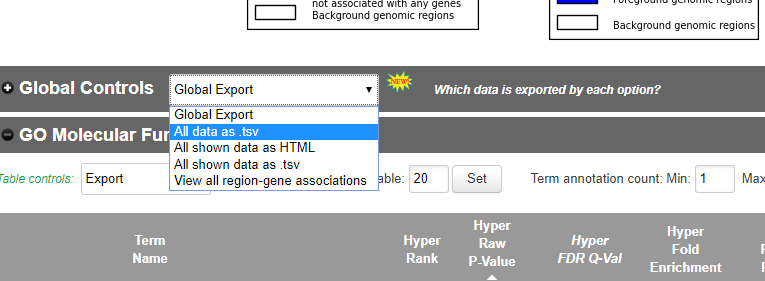

Also the data can be loaded direclty from the output of [rGREAT](https://www.bioconductor.org/packages/release/bioc/html/rGREAT.html) R package. Loading directly the GreatObject.

```r
# Loading from exported csv
Great.files <- c(system.file("extdata", "MM10.GREAT.KO.uGvsMac.bed.tsv",
                              package = "GeneSetCluster"),
                  system.file("extdata", "MM10.GREAT.WT.uGvsMac.bed.tsv",
                              package = "GeneSetCluster"))
# Create the object
Great.Object1 <- LoadGeneSets(file_location = Great.files,
                              groupnames= c("KO", "WT"),
                              P.cutoff = 0.05,
                              Mol.cutoff = 10,
                              Source = "Great",
                              Great.Background = FALSE,
                              type = "Canonical_Pathways",
                              topranks = 20,
                              structure = "SYMBOL",
                              Organism = "org.Mm.eg.db",
                              seperator = ",")
```

```
## [=========================================================]
```

```
## [<<<<            LoadGeneSets START                  >>>>>]
```

```
## Loading data from C:/Users/asier.ortega/AppData/Local/Temp/Rtmp8gYTj8/Rinst96032635904/GeneSetCluster/extdata/MM10.GREAT.KO.uGvsMac.bed.tsv
```

```
## Loading data from C:/Users/asier.ortega/AppData/Local/Temp/Rtmp8gYTj8/Rinst96032635904/GeneSetCluster/extdata/MM10.GREAT.WT.uGvsMac.bed.tsv
```

```
## Loading Splitting Great types passing cutoff
```

```
## [<<<<<               LoadGeneSets END               >>>>>>]
```

```
## [=========================================================]
```

```
## [You may want to process CombineGeneSets next.            ]
```

```
## [or merge objects using MergeObjects                     ]
```

```
## [or select certain types from objects using ManageGeneSets]
```

Recommended is to inspect the labels, if there are multiple experiments the labels can be compared.

For investigate the metafiles check the experiment data and the metainfo to make sure that the PathwayObject matches your experiment(s).

```r
ShowExperimentdata(Object =Great.Object1)
```

```
##              Groupnames Length
## Experiment_1         KO     20
## Experiment_2         KO     20
## Experiment_3         KO     10
## Experiment_4         KO     20
## Experiment_5         WT     20
## Experiment_6         WT     20
## Experiment_7         WT     20
## Experiment_8         WT     20
##                                                                                                                          file_location
## Experiment_1 C:/Users/asier.ortega/AppData/Local/Temp/Rtmp8gYTj8/Rinst96032635904/GeneSetCluster/extdata/MM10.GREAT.KO.uGvsMac.bed.tsv
## Experiment_2 C:/Users/asier.ortega/AppData/Local/Temp/Rtmp8gYTj8/Rinst96032635904/GeneSetCluster/extdata/MM10.GREAT.KO.uGvsMac.bed.tsv
## Experiment_3 C:/Users/asier.ortega/AppData/Local/Temp/Rtmp8gYTj8/Rinst96032635904/GeneSetCluster/extdata/MM10.GREAT.KO.uGvsMac.bed.tsv
## Experiment_4 C:/Users/asier.ortega/AppData/Local/Temp/Rtmp8gYTj8/Rinst96032635904/GeneSetCluster/extdata/MM10.GREAT.KO.uGvsMac.bed.tsv
## Experiment_5 C:/Users/asier.ortega/AppData/Local/Temp/Rtmp8gYTj8/Rinst96032635904/GeneSetCluster/extdata/MM10.GREAT.WT.uGvsMac.bed.tsv
## Experiment_6 C:/Users/asier.ortega/AppData/Local/Temp/Rtmp8gYTj8/Rinst96032635904/GeneSetCluster/extdata/MM10.GREAT.WT.uGvsMac.bed.tsv
## Experiment_7 C:/Users/asier.ortega/AppData/Local/Temp/Rtmp8gYTj8/Rinst96032635904/GeneSetCluster/extdata/MM10.GREAT.WT.uGvsMac.bed.tsv
## Experiment_8 C:/Users/asier.ortega/AppData/Local/Temp/Rtmp8gYTj8/Rinst96032635904/GeneSetCluster/extdata/MM10.GREAT.WT.uGvsMac.bed.tsv
```

```r
ShowMeta(Object = Great.Object1)
```

```
##              source                  type structure     organism Groups
## Experiment_1  Great GO Biological Process    SYMBOL org.Mm.eg.db     KO
## Experiment_2  Great GO Cellular Component    SYMBOL org.Mm.eg.db     KO
## Experiment_3  Great GO Molecular Function    SYMBOL org.Mm.eg.db     KO
## Experiment_4  Great       Mouse Phenotype    SYMBOL org.Mm.eg.db     KO
## Experiment_5  Great GO Biological Process    SYMBOL org.Mm.eg.db     WT
## Experiment_6  Great GO Cellular Component    SYMBOL org.Mm.eg.db     WT
## Experiment_7  Great GO Molecular Function    SYMBOL org.Mm.eg.db     WT
## Experiment_8  Great       Mouse Phenotype    SYMBOL org.Mm.eg.db     WT
##              seperator Data cluster.method highlight order.group loaded
## Experiment_1         , List             NA        NA          NA   Auto
## Experiment_2         , List             NA        NA          NA   Auto
## Experiment_3         , List             NA        NA          NA   Auto
## Experiment_4         , List             NA        NA          NA   Auto
## Experiment_5         , List             NA        NA          NA   Auto
## Experiment_6         , List             NA        NA          NA   Auto
## Experiment_7         , List             NA        NA          NA   Auto
## Experiment_8         , List             NA        NA          NA   Auto
##                display mol.signature
## Experiment_1 Condensed           All
## Experiment_2 Condensed           All
## Experiment_3 Condensed           All
## Experiment_4 Condensed           All
## Experiment_5 Condensed           All
## Experiment_6 Condensed           All
## Experiment_7 Condensed           All
## Experiment_8 Condensed           All
```

Following loading of the PathwayObject the distance can be calculated in the combinePathway function. If the data is very large, data can be managed by selecting for types of interest using ManageGeneSets. In this example we are interested in Disease Ontology and Go Biological Process, so we ManageGeneSets to keep those data types and remove the others. The result of the ManageGeneSets we can see using ShowExperimentdata and ShowMeta.

```r
man.Great.Object1 <- ManageGeneSets(Object = Great.Object1, keep.type =c("Disease Ontology","GO Biological Process" ), exclude.type="")
```

```
## [=========================================================]
```

```
## [<<<<<             ManageGeneSets start             >>>>>>]
```

```
## Keeping the following pathways types:
```

```
## Disease Ontology
```

```
## GO Biological Process
```

```
## [<<<<<             ManageGeneSets END               >>>>>>]
```

```
## [=========================================================]
```

```r
ShowExperimentdata(Object =man.Great.Object1 )
```

```
##              Groupnames Length
## Experiment_1         KO     20
## Experiment_5         WT     20
##                                                                                                                          file_location
## Experiment_1 C:/Users/asier.ortega/AppData/Local/Temp/Rtmp8gYTj8/Rinst96032635904/GeneSetCluster/extdata/MM10.GREAT.KO.uGvsMac.bed.tsv
## Experiment_5 C:/Users/asier.ortega/AppData/Local/Temp/Rtmp8gYTj8/Rinst96032635904/GeneSetCluster/extdata/MM10.GREAT.WT.uGvsMac.bed.tsv
```

```r
ShowMeta(Object =man.Great.Object1 )
```

```
##              source                  type structure     organism Groups
## Experiment_1  Great GO Biological Process    SYMBOL org.Mm.eg.db     KO
## Experiment_5  Great GO Biological Process    SYMBOL org.Mm.eg.db     WT
##              seperator Data cluster.method highlight order.group loaded
## Experiment_1         , List             NA        NA          NA   Auto
## Experiment_5         , List             NA        NA          NA   Auto
##                display mol.signature
## Experiment_1 Condensed           All
## Experiment_5 Condensed           All
```

## 2.3 Loading IPA data

IPA is a web-based bioinformatics platform designed for the analysis of high-throughput experimental data, encompassing microarray and next-generation sequencing results. It facilitates functional analysis, integration, and deeper comprehension of data generated from various sources, including gene expression, miRNA, SNP, metabolomics, and proteomics studies. Users can upload their datasets for analysis, allowing for the examination of gene lists, chemicals, or other entities. IPA provides a search function for genes, proteins, chemicals, and drugs, alongside interactive tools for constructing biological networks that represent intricate biological systems.

```r
IPA.files <- c(system.file("extdata", "MM10.IPA.KO.uGvsMac.Canonical_pathways.xls", package = "GeneSetCluster"),
                 system.file("extdata", "MM10.IPA.WT.uGvsMac.Canonical_pathways.xls", package = "GeneSetCluster"),
                 system.file("extdata", "MM10.IPA.KO.uGvsMac.Functional_annotations.xls", package = "GeneSetCluster"),
                 system.file("extdata", "MM10.IPA.WT.uGvsMac.Functional_annotations.xls", package = "GeneSetCluster"))
canonical.files <- IPA.files[grep("Canonical", IPA.files)] # interested in canonical files

IPA.object1 <- LoadGeneSets(file_location = canonical.files,
                          groupnames= c("KO", "WT"),
                          P.cutoff = 1.3,
                          Mol.cutoff = 5,
                          Source = "IPA",
                          type = "Canonical_Pathways",
                          structure = "SYMBOL",
                          seperator = ",",
                          Organism = "org.Mm.eg.db")
```

```
## [=========================================================]
```

```
## [<<<<            LoadGeneSets START                  >>>>>]
```

```
## Loading data from C:/Users/asier.ortega/AppData/Local/Temp/Rtmp8gYTj8/Rinst96032635904/GeneSetCluster/extdata/MM10.IPA.KO.uGvsMac.Canonical_pathways.xls
```

```
## Loading data from C:/Users/asier.ortega/AppData/Local/Temp/Rtmp8gYTj8/Rinst96032635904/GeneSetCluster/extdata/MM10.IPA.WT.uGvsMac.Canonical_pathways.xls
```

```
## Loading IPA Canonical_Pathways
```

```
## [<<<<<               LoadGeneSets END               >>>>>>]
```

```
## [=========================================================]
```

```
## [You may want to process CombineGeneSets next.            ]
```

```
## [or merge objects using MergeObjects                     ]
```

```
## [or select certain types from objects using ManageGeneSets]
```

## 2.4 Creating PathwayObject manually

Sometimes the tool used for GSA is not available o we would like to create the object in a more specific way. For those cases we can create the PathwayObject manually. We only need to specify the pathway IDs, the genes, name of the groups, the structure, the separator used in genes, source and organism.

```r
# Loading from GSEA results files:
GSEA.files <- c(system.file("extdata", "Covid19AI_Healthy_GSEA.csv",
                            package = "GeneSetCluster"),
               system.file("extdata", "Covid193Mo_Healthy_GSEA.csv",
                            package = "GeneSetCluster"),
               system.file("extdata", "Covid196Mo_Healthy_GSEA.csv",
                            package = "GeneSetCluster"))

file_1 <- read.csv(GSEA.files[1])
file_2 <- read.csv(GSEA.files[2])
file_3 <- read.csv(GSEA.files[3])
head(file_1$ID) # the pathway IDs
```

```
## [1] "GO:0006334" "GO:0034728" "GO:0065004" "GO:0071824" "GO:0002181"
## [6] "GO:0019886"
```

```r
head(file_1$core_enrichment, n = 1) # the genes, '/' as separator
```

```
## [1] "8358/8355/8342/8356/8352/3009/333932/126961/8368/3018/8970/8…"
```

```r
object1 <- ObjectCreator(Pathways = c(file_1$ID, file_2$ID, file_3$ID),

                         Molecules = c(file_1$core_enrichment, file_2$core_enrichment, file_3$core_enrichment),

                         Groups = c(rep("AI",  times = nrow(file_1)),
                                    rep("3Mo", times = nrow(file_2)),
                                    rep("6Mo", times = nrow(file_3))),

                         structure = "ENTREZID", Type="", sep="/", Source="GSEA", organism="org.Hs.eg.db")
```

```
## [=========================================================]
```

```
## [<<<<            ObjectCreator START                 >>>>>]
```

```
## [<<<<<               ObjectCreator END              >>>>>>]
```

```
## [=========================================================]
```

```
## [You may want to process CombineGeneSets next.            ]
```

```
## [or merge objects using MergeObjects                     ]
```

```
## [or select certain types from objects using ManageGeneSets]
```

# 3 Distance calculation, combining the gene-sets

Following all the setup of the pathwayObject we can now combine and cluster the Gene-Sets. The CombineGeneSets function calculates the distance between Gene-Sets which is further used for clustering and seriation-based (cluster-independent) approach.

The distances are calculated for two approaches considering Unique Gene-sets and considering Unique Pathways. Automatically CombineGeneSets will calculate the distances for both options. The result matrix for unique Gene-set will be stored in Data.RR slot and unique Pathway in DataPathways.RR slot.

Briefly: In Gene Set Analysis (GSA), gene sets often overlap, causing redundancy and bias in cluster interpretation.

The updated GeneSetCluster package addresses this with the “Unique Pathway” method, which treats gene sets with the same label as unique by combining their genes. This eliminates duplication, streamlines the analysis, and clarifies gene set distinctions. As a result, comparisons between studies are easier, and biological interpretations are more accurate, helping researchers identify key pathways and genes more precisely.

- uniquePathway = FALSE: This option considers gene sets as they are, including any duplicates. This approach maintains the original structure of the gene sets without combining overlapping genes.
- uniquePathway = TRUE: This option treats gene sets with the same label as unique by combining their genes. This eliminates duplication, streamlines the analysis, and clarifies gene set distinctions.

These options allow researchers to choose between maintaining the original gene set structure or simplifying the analysis by eliminating redundancies. The threads parameter indicates the number of cores to use in order to parallelize.

```r
GSEA.Object2 <- CombineGeneSets(Object = GSEA.Object1, threads=2)
```

```
## [=========================================================]
```

```
## [<<<<            CombineGeneSets START               >>>>>]
```

```
## Combining experiments
```

```
## preparing condensed display
```

```
## calulating RR
```

```
## Parallelizing processes, 2 cores have been selected.
```

```
## [<<<<<             CombineGeneSets END              >>>>>>]
```

```
## [=========================================================]
```

```
## [You may want to process ClusterGeneSets next.            ]
```

```r
print(GSEA.Object2)
```

```
## The PathwayObject contians:
## Total number of pathways: 229
## Groups: IA  Mo3  Mo6
## Distances calculated: YES
## Traditional clustering performed: NOT processed
## Seriation-based clustering performed: NOT processed
## Tissue enrichment for traditional clustering performed: NOT processed
## Tissue enrichment for seriation-based clustering performed: NOT processed
## STRINGdb performed: NOT processed
```

# 4 Clustering

The main idea of GeneSetCluster is grouping the different Gene-sets based on their similarity or distance.

There are two clustering approaches: classic (or cluster-dependent) approach and seriation-based (or cluster-independent) approach. The main differences between them is that in the classic approach must be specified the number of cluster to obtain.

## 4.1 Classic or cluster-dependent approach

We can apply clustering (kmeans or hierarchical clustering) approaches to group pathways based on distance values. As in this approach we must specified the number of clusters to generate, firstly we need to know the optimal number of clusters to know how many clusters to generate.

As mentioned above, we calculated the distances for two approaches considering unique Gene-sets or unique Pathways, with the parameter uniquePathway.

```r
OptimalGeneSets(Object = GSEA.Object2, uniquePathways=FALSE ,method = "silhouette", max_cluster= 24, cluster_method = "kmeans", main= "Kmeans for 24 clusters")
```

```
## [=========================================================]
```

```
## [<<<<            OptimalGeneSets START               >>>>>]
```

```
## Finding optimal number of clusters
```

```
## Clustering method =  kmeans
```

```
## Optimizing method =  silhouette
```

```
## [<<<<<             OptimalGeneSets END              >>>>>>]
```

```
## [=========================================================]
```

```
## [You may want to process ClusterGeneSets next.            ]
```

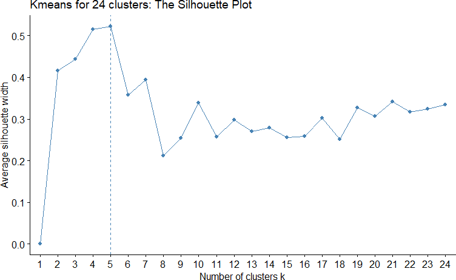

```r
OptimalGeneSets(Object = GSEA.Object2, uniquePathways=TRUE ,method = "silhouette", max_cluster= 24, cluster_method = "kmeans", main= "Kmeans for 24 clusters")
```

```
## [=========================================================]
```

```
## [<<<<            OptimalGeneSets START               >>>>>]
```

```
## Finding optimal number of clusters
```

```
## Clustering method =  kmeans
```

```
## Optimizing method =  silhouette
```

```
## [<<<<<             OptimalGeneSets END              >>>>>>]
```

```
## [=========================================================]
```

```
## [You may want to process ClusterGeneSets next.            ]
```

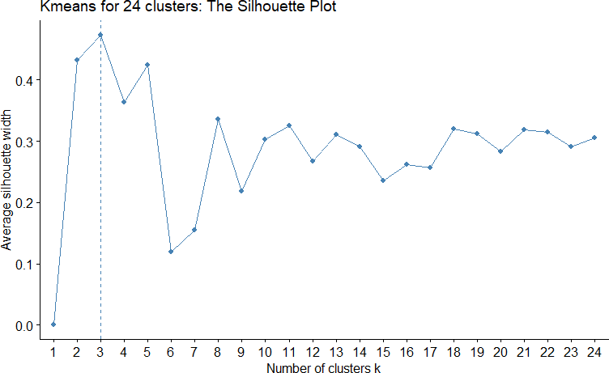

Once that the clusters are generated the functional annotation will be performed using the Gene-sets that make up the clusters. Overrepresentation analysis (ORA) using all the genes in a cluster and in the case of having GO terms a semantic enrichment will be performe.

```r
GSEA.Object3 <- ClusterGeneSets(Object = GSEA.Object2,
                                clusters = 5,
                                method = "kmeans")
```

```
## [=========================================================]
```

```
## [<<<<            ClusterGeneSets START               >>>>>]
```

```
## Using all Gene sets
```

```
## Running kmeans
```

```
## Ordering pathway clusters
```

```
##
## Calculating ORA and Semantic enrichment per cluster for Unique Gene-sets...
```

```
##
## Calculating ORA per cluster...
```

```
## Performing ORA for 5 clusters and choosing the most overrepresented pathway...
```

```
##
## Performing Semantic enrichment per cluster...
```

```
## Performing keyword enrichment for 5 group(s) of pathways.
```

```
##
## Calculating ORA and Semantic enrichment per cluster for Unique Pathways...
```

```
##
## Calculating ORA per cluster...
```

```
## Performing ORA for 5 clusters and choosing the most overrepresented pathway...
```

```
##
## Performing Semantic enrichment per cluster...
```

```
## Performing keyword enrichment for 5 group(s) of pathways.
```

```
## [<<<<<             ClusterGeneSets END              >>>>>>]
```

```
## [=========================================================]
```

```
## [You may want to process HighlightGeneSets next.            ]
```

```
## [You may want to plot the results using PlotGeneSets next. ]
```

Once the clusters are generated we can plot the heatmap to see the result. We can include the functional annotation with the arguments **doORA** and **wordcloud** to show the ORA of the genes that compose each cluster and the semantic enrichment (only when using GO terms), respectively.

First, we will plot the data considering all gene sets as unique. This means that if different datasets are enriched in the same pathway (with the same ID), they will still be treated as distinct. For that set uniquePathways argument as FALSE.

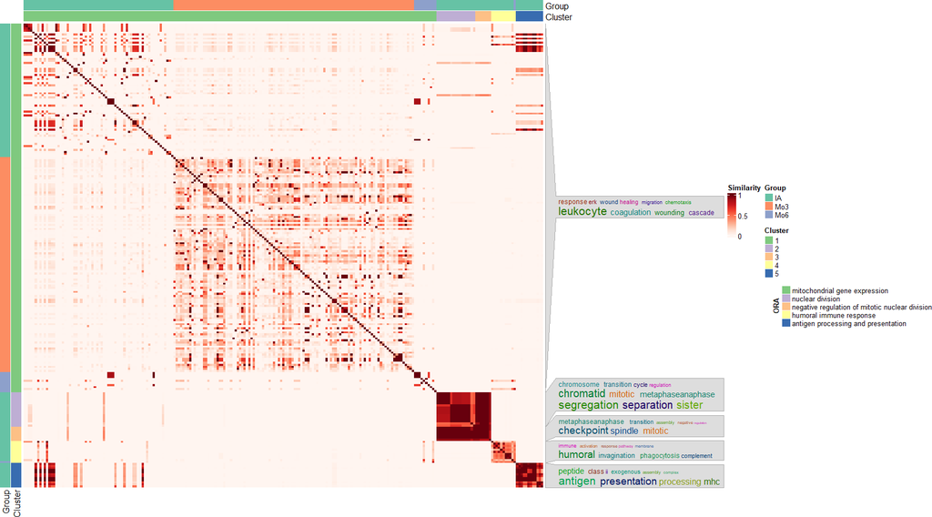

```r
p <- PlotGeneSets(Object = GSEA.Object3, uniquePathways = FALSE,
                  doORA = TRUE, wordcloud = TRUE)
```

From the heatmap, we observe that clusters 2, 3, 4, and 5 contain gene sets with high similarity values, indicating closely related gene sets. In contrast, cluster 1 contains gene sets with low similarity values. Despite this, we notice that cluster 1 can be further divided into two or three subclusters. To achieve this, we will use the **BreakUpCluster** method. While it is apparent in this case, we can also use the **optimalGeneSets** function to determine the optimal number of subclusters for cluster 1. For that note that we are specifying for the cluster we want to break up.

```r
OptimalGeneSets(Object = GSEA.Object3, uniquePathways=FALSE , cluster = 1, method = "silhouette", max_cluster= 24, cluster_method = "kmeans", main= "Kmeans for 24 clusters")
```

```
## [=========================================================]
```

```
## [<<<<            OptimalGeneSets START               >>>>>]
```

```
## Finding optimal number of clusters
```

```
## Clustering method =  kmeans
```

```
## Optimizing method =  silhouette
```

```
## [<<<<<             OptimalGeneSets END              >>>>>>]
```

```
## [=========================================================]
```

```
## [You may want to process ClusterGeneSets next.            ]
```

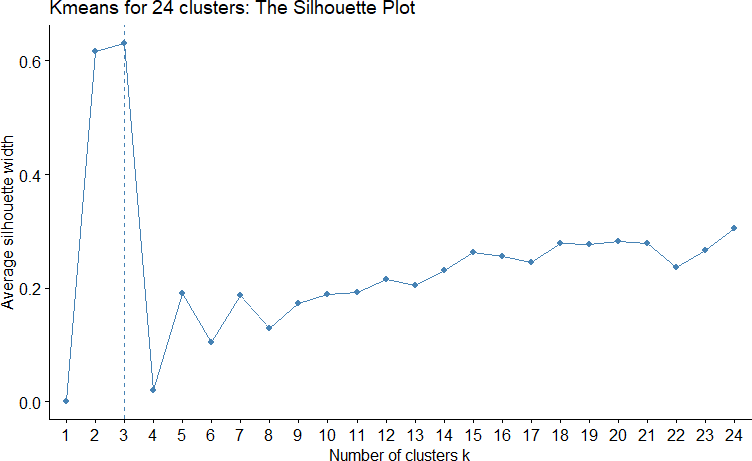

Now we are going to divide cluster 1 into 3 subclusters. We need to specify the cluster we want to break up in the breakup.cluster argument, and in how many clusters we want to split it.

```r
GSEA.Object3.1 <- BreakUpCluster(Object = GSEA.Object3, uniquePathways = FALSE,
                                 breakup.cluster = 1, sub.cluster = 3)
```

```
## [=========================================================]
```

```
## [<<<<            BreakUpCluster START                >>>>>]
```

```
## Ordering pathway clusters
```

```
##
## Calculating ORA and Semantic enrichment per cluster for Unique Pathways...
```

```
##
## Calculating ORA per cluster...
```

```
## Performing ORA for 7 clusters and choosing the most overrepresented pathway...
```

```
##
## Performing Semantic enrichment per cluster...
```

```
## Performing keyword enrichment for 7 group(s) of pathways.
```

```
## [<<<<<             BreakUpCluster END               >>>>>>]
```

```
## [=========================================================]
```

```
## [You may want to process HighlightGeneSets next.           ]
```

```
## [You may want to plot the results using PlotGeneSets next. ]
```

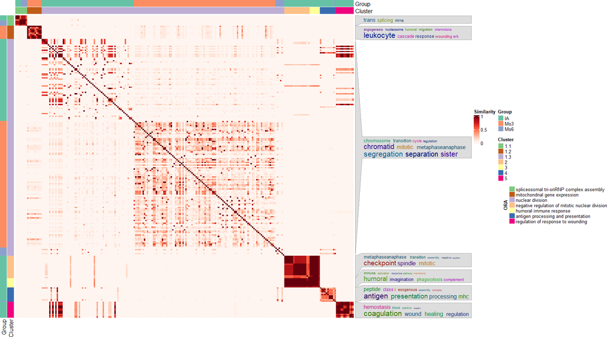

```r
p <- PlotGeneSets(Object = GSEA.Object3.1, uniquePathways = FALSE,
                  doORA = TRUE, wordcloud = TRUE)
```

In this new heatmap, we see that the old cluster 1 has been separated into 3 different clusters. This improves the clustering, as cluster 1 now consists of 3 subclusters, with 2 of them (1.1 and 1.2) showing high similarity. Indeed, this new two subcluster could biologically relevant or informative. If desired, we could further subcluster 1.3 into more subclusters using the same steps.

Now, we will plot the same dataset while treating pathways as unique. This means gene sets enriched in the same pathway (with the same ID) will be combined by merging their constituent genes. In this way, we will eliminate repeated pathways.

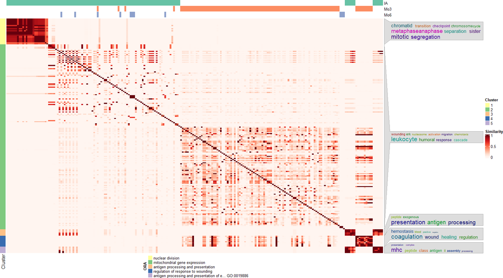

```r
p <- PlotGeneSets(Object = GSEA.Object3.1, uniquePathways = TRUE,
                  doORA = TRUE, wordcloud = TRUE)
```

In the following scenario, we encounter an extreme case where the optimal solution suggests subclustering into 21 clusters. However, such granularity may not be practical. Therefore, we will select a smaller yet appropriate number of clusters. For example 6 subclusters.

```r
OptimalGeneSets(Object = GSEA.Object3.1, uniquePathways=TRUE , cluster=2, method="silhouette", max_cluster=24, cluster_method="kmeans", main="Kmeans for 24 clusters")
```

```
## [=========================================================]
```

```
## [<<<<            OptimalGeneSets START               >>>>>]
```

```
## Finding optimal number of clusters
```

```
## Clustering method =  kmeans
```

```
## Optimizing method =  silhouette
```

```
## [<<<<<             OptimalGeneSets END              >>>>>>]
```

```
## [=========================================================]
```

```
## [You may want to process ClusterGeneSets next.            ]
```

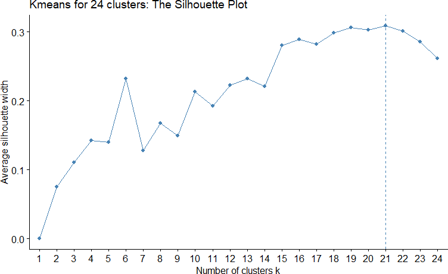

```r
GSEA.Object3.2 <- BreakUpCluster(Object = GSEA.Object3.1, uniquePathways = TRUE,
                                 breakup.cluster = 2, sub.cluster = 6)
```

```
## [=========================================================]
```

```
## [<<<<            BreakUpCluster START                >>>>>]
```

```
## Ordering pathway clusters
```

```
##
## Calculating ORA and Semantic enrichment per cluster for Unique Gene-sets...
```

```
##
## Calculating ORA per cluster...
```

```
## Performing ORA for 10 clusters and choosing the most overrepresented pathway...
```

```
##
## Performing Semantic enrichment per cluster...
```

```
## Performing keyword enrichment for 10 group(s) of pathways.
```

```
## [<<<<<             BreakUpCluster END               >>>>>>]
```

```
## [=========================================================]
```

```
## [You may want to process HighlightGeneSets next.           ]
```

```
## [You may want to plot the results using PlotGeneSets next. ]
```

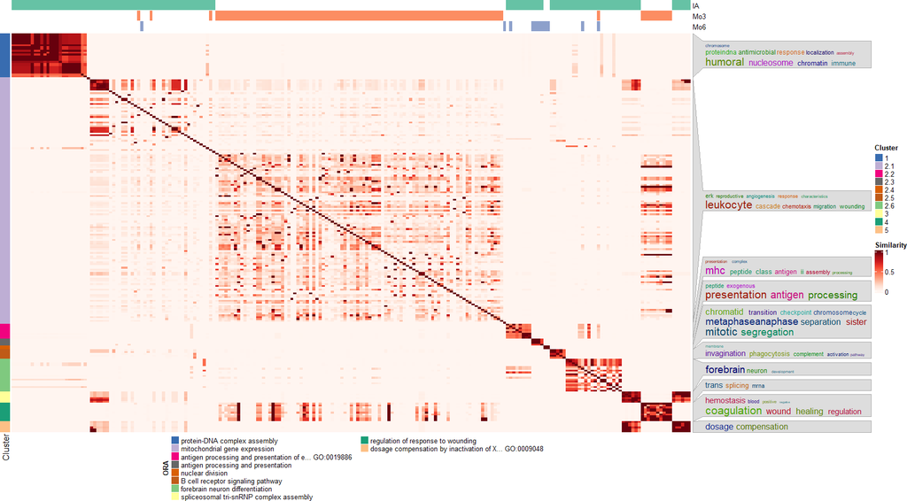

```r
p <- PlotGeneSets(Object = GSEA.Object3.2, uniquePathways = TRUE,
                  doORA = TRUE, wordcloud = TRUE)
```

Thus, we’ve derived five new subclusters (2.2, 2.3, 2.4, 2.5, 2.6) with considerable similarity.

## 4.2 Seriation-based or cluster-independent approach

Classic or cluster-dependent approaches, such as k-means or hierarchical clustering, have several limitations. They require specifying the number of clusters beforehand, which can lead to suboptimal grouping and inclusion of dissimilar gene sets within the same cluster, reducing biological relevance. These methods are sensitive to outliers, can miss subtle relationships, and often result in overfitting, capturing noise rather than meaningful groups.

To address these limitations, we can use seriation-based or cluster-independent approach. The seriation-based clustering method utilizes different seriation algorithms to group gene sets by similarities, avoiding forcing all gene sets into clusters. The selected seriation method is determined by calculating a score based on loss functions to select the most suitable one for each case.

If we want to use a specific seriation method, it can be specified with the **use_method** argument. To functionally annotate only the largest clusters, we need to set a minimum number of gene sets required to form a cluster. This avoids annotating very small clusters. There is an automatic way to determine the optimal minimum number based on our dataset, but it can also be set manually using **nPathways** argument.

So we will run the seriation-based approach.

```r
GSEA.Object3 <- ClusterIndependentGeneSet(Object = GSEA.Object3,
                                          use_method = NULL, nPathways = "optimal")
```

```
## Performing the estimation for all the pathways...
```

```
##
## Computing the loss functions...
```

```
##
## Performing the estimation for unique pathways...
```

```
##
## Computing the loss functions...
```

```
## [=============================================================]
```

```
## [<<<<               SetPathway START                >>>>>]
```

```
## The optimal number of minimum Gene-sets for Unique Gene-set approach is 10
```

```
## The optimal number of minimum Pathways for Unique Pathway approach is 8
```

```
##
## Calculating ORA and Semantic enrichment per cluster for Unique Gene-sets...
```

```
##
## Calculating ORA per cluster...
```

```
## Performing ORA for 4 clusters and choosing the most overrepresented pathway...
```

```
##
## Performing Semantic enrichment per cluster...
```

```
## Performing keyword enrichment for 4 group(s) of pathways.
```

```
##
## Calculating ORA and Semantic enrichment per cluster for Unique Pathways...
```

```
##
## Calculating ORA per cluster...
```

```
## Performing ORA for 5 clusters and choosing the most overrepresented pathway...
```

```
##
## Performing Semantic enrichment per cluster...
```

```
## Performing keyword enrichment for 5 group(s) of pathways.
```

```
## [<<<<               SetPathway ends                >>>>>]
```

```
## [============================================================]
```

Now we plot it using **PlotPathwayCluster** method, where as in the PlotGeneSets, we have to specify if we want to use the unique GeneSets or unique Pathway apporach, and the functional annotation to show.

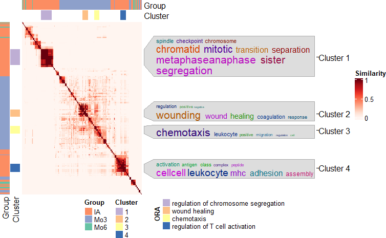

```r
p <- PlotPathwayCluster(GSEA.Object3, uniquePathways = FALSE,
                        doORA = TRUE, wordcloud = TRUE)
```

We can see that the selected seriation method arranges the distance matrix into clusters with high similarity. While the largest clusters are easily noted, some medium-sized ones may be more relevant. To annotate these, we can adjust the minimum number of gene sets needed to form a cluster using the **SetPathway** method.

```r
paste0("Optimal minimum number of GeneSets to form a Cluster considering unique Gene-sets: ", GSEA.Object3@plot$aka3Independent$optimalNumberPathway)
```

```
## [1] "Optimal minimum number of GeneSets to form a Cluster considering unique Gene-sets: 10"
```

```r
paste0("Optimal minimum number of GeneSets to form a Cluster considering unique Pathways: ", GSEA.Object3@plot$aka3IndependentUnique$optimalNumberPathway)
```

```
## [1] "Optimal minimum number of GeneSets to form a Cluster considering unique Pathways: 8"
```

So we’re going to set the minimum number of Genesets in 6 to annotate those clusters that are smaller. And plot it

```r
GSEA.Object3min6 <- SetPathway(GSEA.Object3, nPathways = 6)
```

```
## [=============================================================]
```

```
## [<<<<               SetPathway START                >>>>>]
```

```
## Setting 6 as minimum number of elements to consider a cluster...
```

```
##
## Calculating ORA and Semantic enrichment per cluster for Unique Gene-sets...
```

```
##
## Calculating ORA per cluster...
```

```
## Performing ORA for 12 clusters and choosing the most overrepresented pathway...
```

```
##
## Performing Semantic enrichment per cluster...
```

```
## Performing keyword enrichment for 12 group(s) of pathways.
```

```
##
## Calculating ORA and Semantic enrichment per cluster for Unique Pathways...
```

```
##
## Calculating ORA per cluster...
```

```
## Performing ORA for 9 clusters and choosing the most overrepresented pathway...
```

```
##
## Performing Semantic enrichment per cluster...
```

```
## Performing keyword enrichment for 9 group(s) of pathways.
```

```
## [<<<<               SetPathway ends                >>>>>]
```

```
## [============================================================]
```

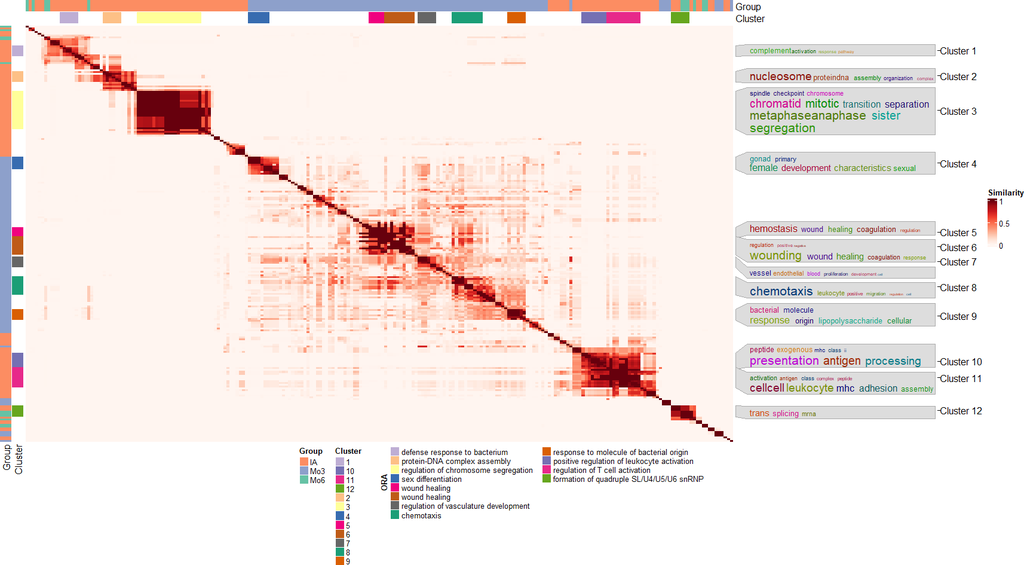

```r
p <- PlotPathwayCluster(GSEA.Object3min6, uniquePathways = FALSE,
                        doORA = TRUE, wordcloud = TRUE)
```

Now we’re going to explore the results considering unique Pathways and setting the minimum number of Pathways to 6.

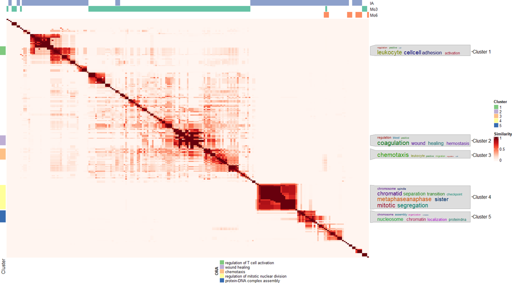

```r
p <- PlotPathwayCluster(GSEA.Object3, uniquePathways = TRUE,
                        doORA = TRUE, wordcloud = TRUE)
```

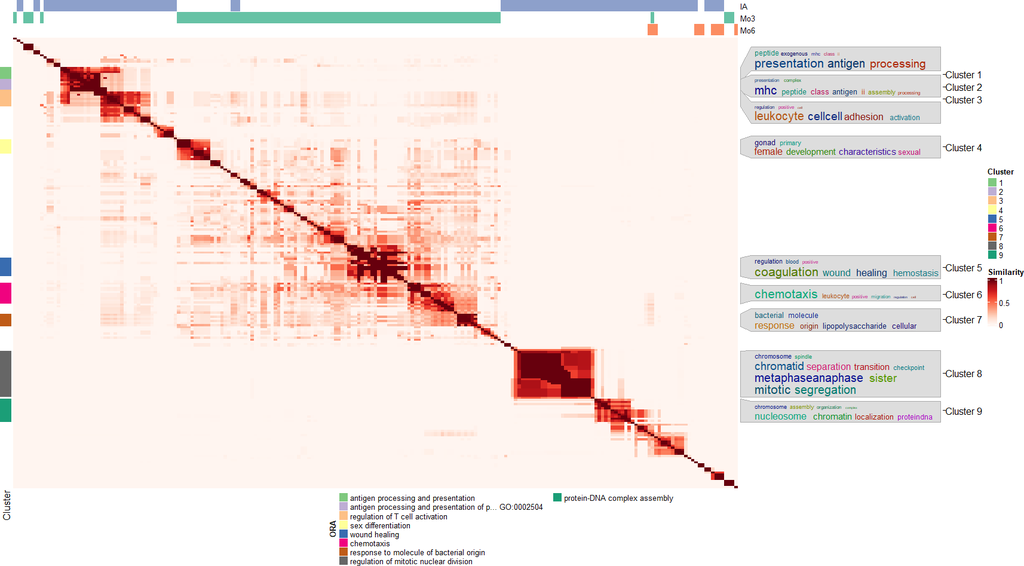

```r
p <- PlotPathwayCluster(GSEA.Object3min6, uniquePathways = TRUE,
                        doORA = TRUE, wordcloud = TRUE)
```

It is worth to mention that is posible to access to all the ORA and GO terms results of each cluster. In case we would like to explore them mor ein detail.

```r
head(GSEA.Object3@functionalAnnot$Geneset$ORA[[1]]) # each slot of the list refers to each cluster
```

```
##                    ID                   Description GeneRatio   BgRatio
## GO:0140053 GO:0140053 mitochondrial gene expression  102/1546 163/18870
## GO:0002181 GO:0002181       cytoplasmic translation   91/1546 156/18870
## GO:0032543 GO:0032543     mitochondrial translation   80/1546 130/18870
## GO:0006399 GO:0006399        tRNA metabolic process   96/1546 197/18870
## GO:0008033 GO:0008033               tRNA processing   76/1546 134/18870
## GO:0044782 GO:0044782           cilium organization  133/1546 407/18870
##                  pvalue     p.adjust       qvalue
## GO:0140053 2.092895e-69 1.259504e-65 6.877913e-66
## GO:0002181 4.128698e-58 1.242325e-54 6.784103e-55
## GO:0032543 9.427812e-54 1.891219e-50 1.032759e-50
## GO:0006399 1.048956e-51 1.578155e-48 8.618003e-49
## GO:0008033 1.994432e-47 2.400498e-44 1.310867e-44
## GO:0044782 1.388571e-46 1.392737e-43 7.605473e-44
##                                                                                                                                                                                                                                                                                                          …
## GO:0140053                                                                                                                                                                                                               26589/79736/51318/285367/80298/51069/6182/63875/64216/10922/…
## GO:0002181                                                                                                                                                                                                                                                                                               …
## GO:0032543                                                                                                                                                                                                                                                                                               …
## GO:0006399                                                                                                                                                                                                                                              57570/54938/3028/26995/3035/55006/124454/8846/551…
## GO:0008033                                                                                                                                                                                                                                                                                               …
## GO:0044782 9148/4851/4739/8555/2316/30844/1453/3985/146057/80199/51134/…
##            Count
## GO:0140053   102
## GO:0002181    91
## GO:0032543    80
## GO:0006399    96
## GO:0008033    76
## GO:0044782   133
```

```r
head(GSEA.Object3@functionalAnnot$Geneset$GO[[1]]) # each slot of the list refers to each cluster
```

```
##         df...1. X.log10.df.p.
## 1          acid    0.05078841
## 2    activation    2.93162671
## 3      adhesion    2.18922530
## 4  angiogenesis    3.84760300
## 5 antimicrobial    2.70324194
## 6      assembly    1.13612490
```

# 5 Additional features

GeneSetCluster 2.0 has some additional functionalities that may be of interest to further explore our Gene-sets.

## 5.1 Network visualization

Using the **PlotGeneNetworks** method on the PathwayObject plots a network. Plotting the network shows the relationship of Gene set with other gene sets in context with the minimum number of distance between them.

We need to specify if we want to plot the unique Gene-set or unique Pathway approach, and also which clustering method either classic or seriation-based. We specify the minimum distance between the genest with the parameter RRmin, that goes from 0 to 1.

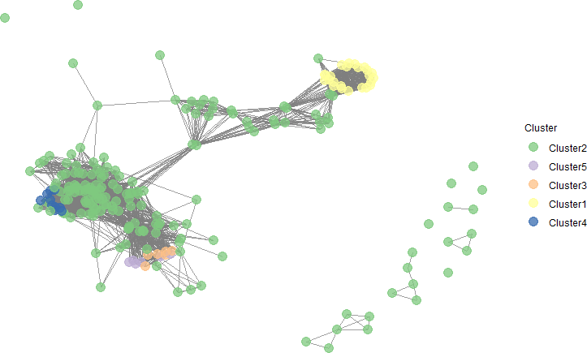

```r
PlotGeneNetworks(GSEA.Object3, uniquePathways = TRUE, clusterIndependent = FALSE,
             labels = FALSE, RRmin = 0.1)
```

We can see how the Gene-sets within the same cluster are grouped and connected in the network. Increasing the value of RRmin makes us stricter with the minimum distance that two Gene-Sets must have to be connected. For example we will use a RRmin of 0.5.

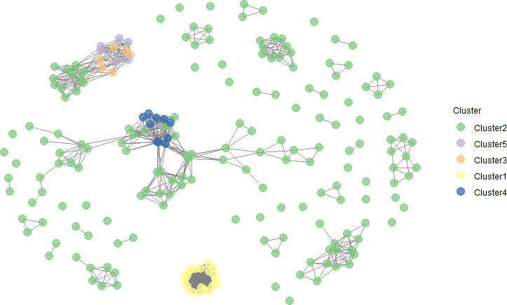

```r
PlotGeneNetworks(GSEA.Object3, uniquePathways = TRUE, clusterIndependent = FALSE,
             labels = FALSE, RRmin = 0.5)
```

Now we plot the seriation-based or cluster-independent approach. And increasing the RRmin.

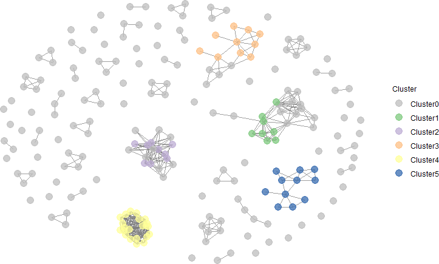

```r
PlotGeneNetworks(GSEA.Object3, uniquePathways = TRUE, clusterIndependent = TRUE,
             labels = FALSE, RRmin = 0.75)
```

## 5.2 Extracting genes from clusters

GeneSetCluster allows the option to extract genes belonging to clusters. Again we must take into account whether we want the genes considering unique GeneSets or Pathways and the type of clustering.

```r
head(GenesPerGeneSet(Object = GSEA.Object3, uniquePathways = FALSE, clusterIndependent = FALSE))
```

```
## [=============================================================]
```

```
## [<<<<               GenesPerGeneSet START                >>>>>]
```

```
## Unique Gene-sets selected.
```

```
## Extracting genes for all 5 clusters
```

```
## [<<<<               GenesPerGeneSet ends                >>>>>]
```

```
## [============================================================]
```

```
##        Cluster_1 Cluster_2 Cluster_3 Cluster_4 Cluster_5
## 8358           1         0         0         0         0
## 7555           1         0         0         0         0
## 135            1         0         0         0         0
## 3512           1         0         0         1         0
## 114548         1         0         0         0         0
## 6035           1         0         0         0         0
```

```r
head(GenesPerGeneSet(Object = GSEA.Object3, uniquePathways = TRUE, clusterIndependent = TRUE))
```

```
## [=============================================================]
```

```
## [<<<<               GenesPerGeneSet START                >>>>>]
```

```
## Obtaining genes from Cluster-independent approach...
```

```
## Unique Pathways selected.
```

```
## Extracting genes for all 5 clusters
```

```
## [<<<<               GenesPerGeneSet ends                >>>>>]
```

```
## [============================================================]
```

```
##        Cluster_1 Cluster_2 Cluster_3 Cluster_4 Cluster_5
## 135            1         1         0         0         0
## 114548         1         0         0         0         0
## 57178          1         0         0         0         0
## 3127           1         0         0         0         0
## 57045          1         0         0         0         0
## 3561           1         0         0         0         0
```

## 5.3 Tissue enrichment analysis

Using the TissueExpressionPerGeneSet function, we can see which tissues the genes in each cluster are enriched in, based on data from the Genotype-Tissue Expression (GTEx) database. Note: this step can take a long time. In total there are 54 tissues.

We can wither specified the specific tissues we want to study or choose all of them. Also GeneSetCluster connects to an API to obtain the data, but also there is the possibility to run the analysis locally downloading the database.

Link of downloading the database: https://figshare.com/articles/dataset/TissueDatabase/25965664

When we run the method we need to specify to do the enrichment either in the data where we perform classic (clusterIndependent = FALSE) or seriation-based clustering (clusterIndependent = TRUE).

```r
GSEA.Object3 <- TissueExpressionPerGeneSet(Object=GSEA.Object3, clusterIndependent = TRUE, tissues = c("Lung", "Nerve...Tibial", "Whole.Blood", "Liver", "Brain...Amygdala", "Breast...Mammary.Tissue", "Heart...Atrial.Appendage", "Stomach", "Thyroid"))
```

```
## [=========================================================]
```

```
## [<<<<         ObtainTissueExpression START           >>>>>]
```

```
## Selected tissues:
```

```
## Lung
## Nerve...Tibial
## Whole.Blood
## Liver
## Brain...Amygdala
## Breast...Mammary.Tissue
## Heart...Atrial.Appendage
## Stomach
## Thyroid
```

```
## [=============================================================]
```

```
## [<<<<               GenesPerGeneSet START                >>>>>]
```

```
## Obtaining genes from Cluster-independent approach...
```

```
## Unique Pathways selected.
```

```
## Extracting genes for all 4 clusters
```

```
## [<<<<               GenesPerGeneSet ends                >>>>>]
```

```
## [============================================================]
```

```
## [=============================================================]
```

```
## [<<<<               GenesPerGeneSet START                >>>>>]
```

```
## Obtaining genes from Cluster-independent approach...
```

```
## Unique Pathways selected.
```

```
## Extracting genes for all 5 clusters
```

```
## [<<<<               GenesPerGeneSet ends                >>>>>]
```

```
## [============================================================]
```

```
## Performing GTEx API REST query to obtain the GTEx database.
```

```
## Performing GSEA for unique Gene-sets...
```

```
## Performing GSEA for unique Pathways...
```

```
## [=========================================================]
```

```
## [<<<<         ObtainTissueExpression END             >>>>>]
```

```
## [You may want to plot the results using PlotTissueExpression next.]
```

We will plot it using **PlotTissueExpression** method.

```
## [You may want to plot the cluster tissue expression using PlotClusterTissueExpression next.]
```

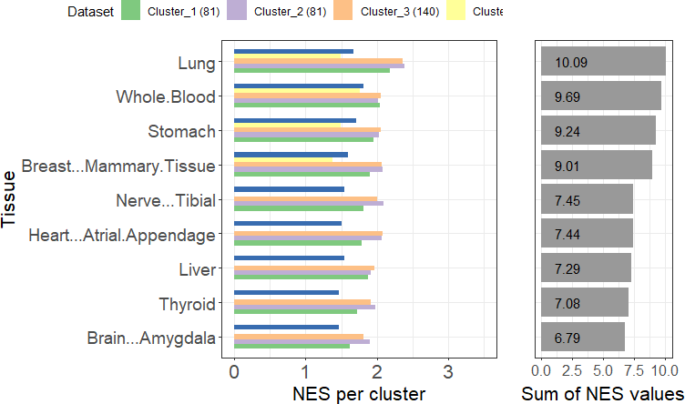

```r
PlotTissueExpression(GSEA.Object3, clusterIndependent = T, uniquePathways = T)
```

In this plot, we can see the number of genes in each cluster, how enriched each cluster is in the selected tissues, and the total sum of all clusters for each tissue.

We also have an argument to show us the Z-scores so that we can visualize it in a better way, in the cases that we are enriching in many genes.

```
## [You may want to plot the cluster tissue expression using PlotClusterTissueExpression next.]
```

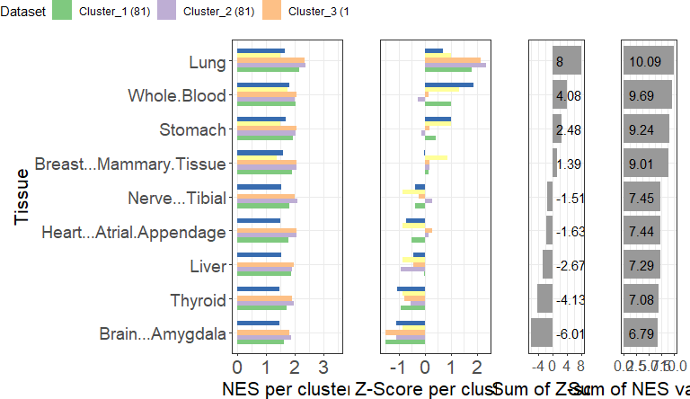

```r
PlotTissueExpression(GSEA.Object3, clusterIndependent = T, uniquePathways = T, showZscore = TRUE)
```

## 5.4 STRINGdb analysis

STRINGdb is a comprehensive database providing crucial information on protein-protein interactions, which aids in understanding the functional relationships within the proteome. GeneSetCluster uses STRINGdb plugin to analyse our GeneSets.

Firstly, we will perform the protein-protein interaction analysis. Again we must take into account whether we want the genes considering unique GeneSets or Pathways and the type of clustering.

```r
GSEA.Object3 <- GetSTRINGdbPerGeneSets(GSEA.Object3, clusterIndependent = T, uniquePathways = T)
```

```
## [==================================================================]
```

```
## [<<<<             GetSTRINGdbPerGeneSets START                >>>>>]
```

```
## [<<<<             GetSTRINGdbPerGeneSets ends                >>>>>]
```

```
## [=================================================================]
```

```
## To view the StringPlots use plotSTRINGdbPerGeneSets
```

For plotting we need to specify the cluster we want to plot.

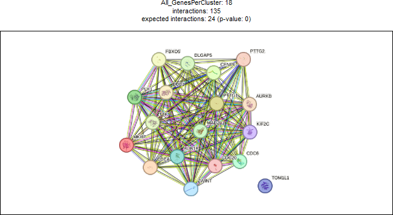

```r
plotSTRINGdbPerGeneSets(GSEA.Object3, plot.cluster = 4)
```

# 6 Shiny Application

This new version introduces a robust and intuitive Shiny application, designed to accommodate new users, particularly clinicians and biologists with no/limited bioinformatics experience. This user-friendly application is hosted on shinyappserver, and alternatively, it can be installed locally.

In the web version, researchers can upload their gene-sets analysis results in a variety of formats (.txt, .xlsx, and .csv) or use the provided Excel template for convenience. Upon selecting essential input fields, such as handling duplicated gene-sets, the default analysis begins applying classic clustering (details in Supplementary Material). The resulting output includes comprehensive clustering information, ORA analysis details for each cluster, gene frequency per cluster, and informative plots illustrating the distance matrix and cluster summaries.

Additionally, the Shiny application supports the uploading of GeneSetCluster object created in the R package, enabling users to continue their analysis online. Likewise, analysis initiated in the app can be exported and continued in the R package.

[Online version link](https://translationalbio.shinyapps.io/genesetcluster/)

To run the shiny application.

```r
run_app()
```

[figure not shown]

Shiny application example